# PTSD Model Analysis

Andrea Stocco & Briana Smith

# Analysis of the PTSD Model “Fast1” Simulations

These simulations were run in July 2019, using the “fast” (lisp) version of the code.

## Loading the Data

First, we load the file produced by the `fast` simulations (in this case, `fast\simulations1.txt`).

```r
data <- read.csv("fast/simulations1.txt")
```

Because of a coding bug, the variable `RetrievedV`, which tracks the *V* value of the chunk being retrieved, was accidentally named `Chunk`. We can easily fix that.

```r
data <- rename(data, RetrievedV = Chunk)
```

## Smoothing the Timestamps

Timestamps vary a bit because of the different retrieval times, which change as function of similarity, history, noise, and any other factor that affects a chunk’s activation level.

To account fo this, we will round up the **Time** variable to the hundreds. We wil also create a second variable, `Day`, which will be an approximation of Time, further rounding up 25 consecutive time points. That corresponds to roughly a simulated day (12.5) for the model, not accounting for day/night cycles.

Finally, we will offset the **Day** variable so that the PTE occurrs when **Day** is zero.

```r
data$Time <- round(data$Time/100)
data$Day <- round(data$Time/25, 0)
data$Day <- data$Day - 12
```

At this point, we have sufficient time points for each value of **Day** to plot smooth, rather than choppy, data lines. As a first step, we will average the values of *V* and *Similarity* across the different **Day** values and values of the traumatic event **PTEV**.

```r
a <- aggregate(data[c("RetrievedV", "ChunkSimilarity", "Traumatic")],
               list(Day=data$Day, PTEV=data$PTEV,
                    S=data$PTES, W=data$IMAGINAL.ACTIVATION,
                    BLL=data$BLL),
               mean)

a$PTEV <- as.factor(a$PTEV)
a$S <- as.factor(a$S)
a$W <- as.factor(a$W)
a$BLL <- as.factor(a$BLL)
```

## Incidence of Traumatic Memories after PTE

In this and the other graphs, we will visualize the effects of different values of **PTEV** across different measurs of similarity **S** betweenthe traumatic event and the daily events (left to right) and across different measures **W** of working memory capacity. Different 5 by 5 grids will generated for different levels of mekory decay **BLL**:

```r
for (bll in unique(a$BLL)) {
  ggplot(subset(a, a$BLL == bll), aes(x=Day, y=Traumatic, col=PTEV)) +
    stat_summary(fun.data = mean_se, geom="line") +
    facet_wrap(~W * ~S) +
    theme_linedraw()
}
```

[output not shown]

## Analysis of Effects of PTEV

Now, we can consider how how the model fares, after the PTE, for different values of **PTEV**. First, we will consider the model’s well-being. That is captured by the **RetrievedV** variable, which captues the mean value of the memories being retrieved. Increased retrieval of traumatic memories leads, of course, to increased **RetrievedV** values.

```r
for (bll in unique(a$BLL)) {
  ggplot(subset(a, a$BLL == bll), aes(x=Day, y=RetrievedV, col=PTEV)) +
    stat_summary(fun.data = mean_se, geom="line") +
    facet_wrap(~W * ~S) +
    theme_linedraw()
}
```

[output not shown]

## Analysis of Effects of PTE on Cognitive Function

We can also consider how well the model is doing cognitively. This is measured by the **ChunkSimilarity** between the retrieved response and the current context. As memories become more intrusive, the similarity is expected to decrease. Decreased similarity means that the response made is not as relevant to the current context.

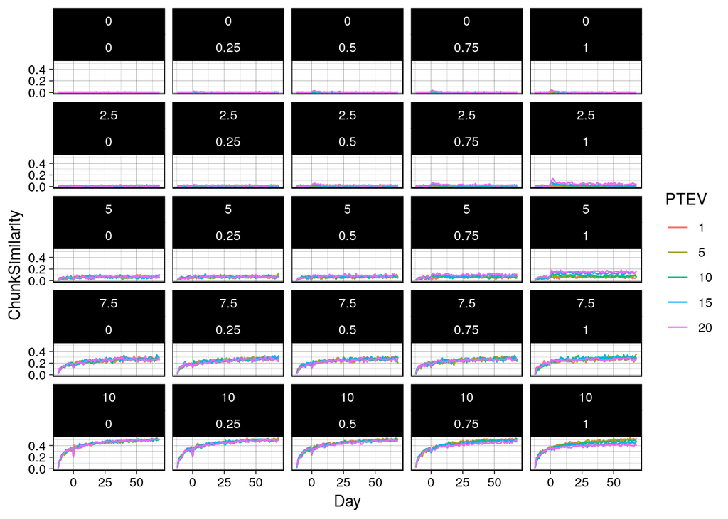

```r
  ggplot(subset(a, a$BLL == 0.9), aes(x=Day, y=ChunkSimilarity, col=PTEV)) +
    stat_summary(fun.data = mean_se, geom="line") +
    facet_wrap(~W * ~S) +
    theme_linedraw()
```

```r
for (bll in unique(a$BLL)) {
  ggplot(subset(a, a$BLL == bll), aes(x=Day, y=ChunkSimilarity, col=PTEV)) +
    stat_summary(fun.data = mean_se, geom="line") +
    facet_wrap(~W * ~S) +
    theme_linedraw()
}
```